# Create a multiplatform app using Ktor and SQLDelight

This tutorial demonstrates how to use IntelliJ IDEA to create an advanced mobile application for iOS and Android using Kotlin Multiplatform. This application is going to:

- Retrieve data over the internet from the public [Launch Library](https://lldev.thespacedevs.com/docs) using Ktor
- Save the data in a local database using SQLDelight.
- Display a list of space rocket launches together with the launch date, results, and a detailed description of the launch.

The application will include a module with shared code for both the iOS and Android platforms. The business logic and data access layers will be implemented only once in the shared module, while the UI of both applications will be native.

[figure not shown]

You will use the following multiplatform libraries in the project:

- [Ktor](https://ktor.io/docs/create-client.html) as an HTTP client for retrieving data over the internet.
- [`kotlinx.serialization`](https://github.com/Kotlin/kotlinx.serialization) to deserialize JSON responses into objects of entity classes.
- [`kotlinx.coroutines`](https://github.com/Kotlin/kotlinx.coroutines) to write asynchronous code.
- [SQLDelight](https://github.com/cashapp/sqldelight) to generate Kotlin code from SQL queries and create a type-safe database API.
- [Koin](https://insert-koin.io/) to provide platform-specific database drivers via dependency injection.

## Create a project

1. In the quickstart, complete the instructions to set up your environment for Kotlin Multiplatform development.
2. In IntelliJ IDEA, select File | New | Project.
3. In the panel on the left, select Kotlin Multiplatform (in Android Studio, the template can be found in the Generic tab of the New Project wizard).
4. Specify the following fields in the New Project window:
   - Name: SpaceTutorial
   - Project ID: com.jetbrains.spacetutorial
5. Select Android and iOS targets.
6. For iOS, select the Do not share UI option. You will implement a native UI for both platforms.
7. Once you've specified all the fields and targets, click Create.

[figure not shown]

## Add Gradle dependencies

To add a multiplatform library to the shared module, add dependency instructions (`implementation`) to the `dependencies {}` block of the relevant source sets in the module's `build.gradle.kts` file.

`kotlinx.serialization` and SQLDelight libraries also require additional configuration.

Change or add lines in the version catalog in the `gradle/libs.versions.toml` file to reflect all necessary dependencies:

1. In the `[versions]` block, check the AGP version and add the rest:

   [versions] agp = "9.0.1" material3 = "1.11.0-alpha07" # ... coroutinesVersion = "1.11.0" dateTimeVersion = "0.8.0" koin = "4.2.2" ktor = "3.5.2" sqlDelight = "2.3.2"
2. In the `[libraries]` block, add the following library references:

   [libraries] ... koin-core = { module = "io.insert-koin:koin-core", version.ref = "koin" } koin-androidx-compose = { module = "io.insert-koin:koin-androidx-compose", version.ref = "koin" } kotlinx-coroutines-core = { module = "org.jetbrains.kotlinx:kotlinx-coroutines-core", version.ref = "coroutinesVersion" } kotlinx-datetime = { module = "org.jetbrains.kotlinx:kotlinx-datetime", version.ref = "dateTimeVersion" } ktor-client-android = { module = "io.ktor:ktor-client-android", version.ref = "ktor" } ktor-client-content-negotiation = { module = "io.ktor:ktor-client-content-negotiation", version.ref = "ktor" } ktor-client-core = { module = "io.ktor:ktor-client-core", version.ref = "ktor" } ktor-client-darwin = { module = "io.ktor:ktor-client-darwin", version.ref = "ktor" } ktor-serialization-kotlinx-json = { module = "io.ktor:ktor-serialization-kotlinx-json", version.ref = "ktor" } sqldelight-android-driver = { module = "app.cash.sqldelight:android-driver", version.ref = "sqlDelight" } sqldelight-native-driver = { module = "app.cash.sqldelight:native-driver", version.ref = "sqlDelight" } sqldelight-runtime = { module = "app.cash.sqldelight:runtime", version.ref = "sqlDelight" }
3. In the `[plugins]` block, specify the necessary Gradle plugins:

   ```
   [plugins]
   # ...
   kotlinxSerialization = { id = "org.jetbrains.kotlin.plugin.serialization", version.ref = "kotlin" }
   sqldelight = { id = "app.cash.sqldelight", version.ref = "sqlDelight" }
   ```

4. Once the version catalog is updated, you're prompted to resync the project. Click the Sync Gradle Changes button to synchronize Gradle files:
5. At the very beginning of the `sharedLogic/build.gradle.kts` file, add the following lines to the `plugins {}` block:

   ```
   plugins {
       // ...
       alias(libs.plugins.kotlinxSerialization)
       alias(libs.plugins.sqldelight)
   }
   ```

6. The common source set requires a core artifact of each library, as well as the Ktor [serialization feature](https://ktor.io/docs/serialization-client.html) to use `kotlinx.serialization`. The iOS and Android source sets also need SQLDelight and Ktor platform drivers.

   In the same `sharedLogic/build.gradle.kts` file, add all the required dependencies:

   ```
   kotlin {
       // ...

       sourceSets {
           commonMain.dependencies {
               implementation(libs.kotlinx.coroutines.core)
               implementation(libs.ktor.client.core)
               implementation(libs.ktor.client.content.negotiation)
               implementation(libs.ktor.serialization.kotlinx.json)
               implementation(libs.sqldelight.runtime)
               implementation(libs.kotlinx.datetime)
               implementation(libs.koin.core)
           }
           androidMain.dependencies {
               implementation(libs.ktor.client.android)
               implementation(libs.sqldelight.android.driver)
           }
           iosMain.dependencies {
               implementation(libs.ktor.client.darwin)
               implementation(libs.sqldelight.native.driver)
           }
       }
   }
   ```

7. Once the dependencies are specified, click the Sync Gradle Changes button to update Gradle files once again.

After the Gradle sync, you are done with the project configuration and can start writing code.

## Create an application data model

- General information about the launch
- Links to images of mission patches
- URLs of articles related to the launch

Create the necessary data classes:

1. In the `sharedLogic/src/commonMain/kotlin/com/jetbrains/spacetutorial` directory, create the `entity` package, then create the `Entity.kt` file inside that package.
2. Declare all the data classes for basic entities:

   import kotlinx.datetime.TimeZone import kotlinx.datetime.toInstant import kotlinx.datetime.toLocalDateTime import kotlinx.serialization.SerialName import kotlinx.serialization.Serializable import kotlin.time.Instant @Serializable data class LaunchStatus( @SerialName("id") val id: Int, @SerialName("name") val name: String, @SerialName(value = "description") val description: String ) @Serializable data class LaunchListResponse( @SerialName("results") val results: List<RocketLaunch>, ) @Serializable data class RocketLaunch( @SerialName("id") val id: String, @SerialName("name") val missionName: String, @SerialName("net") val launchDateUTC: String, @SerialName(value = "image") val image: Image, @SerialName(value = "status") val status: LaunchStatus, ) { var launchYear = Instant.parse(launchDateUTC).toLocalDateTime(TimeZone.UTC).year } @Serializable data class Image( @SerialName("thumbnail_url") val small: String, @SerialName("image_url") val large: String, )

Each serializable class must be marked with the `@Serializable` annotation. The `kotlinx.serialization` plugin automatically generates a default serializer for `@Serializable` classes unless you explicitly pass a link to a serializer in the annotation argument.

The `@SerialName` annotation allows you to redefine field names, which helps to access properties in data classes using more readable identifiers.

## Configure SQLDelight and implement cache logic

The SQLDelight library allows you to generate a type-safe Kotlin database API from SQL queries. During compilation, the generator validates the SQL queries and turns them into Kotlin code that can be used in the shared module.

### Configure SQLDelight

The SQLDelight dependency is already included in the project. To configure the library, open the `sharedLogic/build.gradle.kts` file and add the `sqldelight {}` block at the end. This block contains a list of databases and their parameters:

```
sqldelight {
    databases {
        create("AppDatabase") {
            packageName.set("com.jetbrains.spacetutorial.cache")
        }
    }
}
```

The `packageName` parameter holds the package name for the generated Kotlin sources.

Sync the Gradle project files when prompted, or press double `Shift` and search for the Sync All Gradle, Swift Package Manager projects action.

### Generate the database API

First, create the `.sq` file with all the necessary SQL queries. By default, the SQLDelight plugin looks for `.sq` files in the `sqldelight` folder of the source set:

1. In the `sharedLogic/src/commonMain` directory, create a new `sqldelight` directory.
2. Inside the `sqldelight` directory, create a new directory with the name `com/jetbrains/spacetutorial/cache` to create nested directories for the package.
3. Inside the `cache` directory, create the `AppDatabase.sq` file (with the same name as the database you specified in the `build.gradle.kts` file). All the SQL queries for your application will be stored in this file.
4. The database will contain a table with data about launches. Add the following code to the `AppDatabase.sq` file to create the table and define several functions which you will use later:

   ```
   import kotlin.Boolean;

   CREATE TABLE Launch (
       flightNumber TEXT NOT NULL,
       missionName TEXT NOT NULL,
       launchDateUTC TEXT NOT NULL,
       imageSmall TEXT NOT NULL,
       imageLarge TEXT NOT NULL,
       statusId INTEGER NOT NULL,
       statusName TEXT NOT NULL,
       statusDescription TEXT NOT NULL
   );

   insertLaunch:
   INSERT INTO Launch(flightNumber, missionName, launchDateUTC, imageSmall, imageLarge, statusId, statusName, statusDescription)
   VALUES(?, ?, ?, ?, ?, ?, ?, ?);

   removeAllLaunches:
   DELETE FROM Launch;

   selectAllLaunchesInfo:
   SELECT Launch.*
   FROM Launch;
   ```

5. Generate the corresponding `AppDatabase` interface (which you will initialize with database drivers later on). To do that, run the following command in the terminal, at the root of the project:

   ```
   ./gradlew generateCommonMainAppDatabaseInterface
   ```

   The generated Kotlin code is stored in the `sharedLogic/build/generated/sqldelight` directory.

### Create factories for platform-specific database drivers

To initialize the `AppDatabase` interface, you will pass an `SqlDriver` instance to it. SQLDelight provides multiple platform-specific implementations of the SQLite driver, so you need to create these instances separately for each platform.

While you can achieve this with expected and actual interfaces, in this project, you will use [Koin](https://insert-koin.io/) to try dependency injection in Kotlin Multiplatform.

1. Create an interface for database drivers. To do this, in the `sharedLogic/src/commonMain/kotlin/com/jetbrains/spacetutorial/` directory, create the `cache` package.
2. Create the `DatabaseDriverFactory` interface inside the `cache` package:

   ```
   package com.jetbrains.spacetutorial.cache

   import app.cash.sqldelight.db.SqlDriver

   interface DatabaseDriverFactory {
       fun createDriver(): SqlDriver
   }
   ```

3. Create the class implementing this interface for Android: in the `sharedLogic/src/androidMain/kotlin` directory, create the `com.jetbrains.spacetutorial.cache` package, then create the `AndroidDatabaseDriverFactory.kt` file inside it.
4. On Android, the SQLite driver is implemented by the `AndroidSqliteDriver` class. In the `DatabaseDriverFactory.kt` file, pass the database information and the context link to the `AndroidSqliteDriver` class constructor:

   ```
   package com.jetbrains.spacetutorial.cache

   import android.content.Context
   import app.cash.sqldelight.db.SqlDriver
   import app.cash.sqldelight.driver.android.AndroidSqliteDriver

   class AndroidDatabaseDriverFactory(private val context: Context) : DatabaseDriverFactory {
       override fun createDriver(): SqlDriver {
           return AndroidSqliteDriver(AppDatabase.Schema, context, "launch.db")
       }
   }
   ```

5. For iOS, in the `shared/src/iosMain/kotlin/com/jetbrains/spacetutorial/` directory, create the `cache` package.
6. Inside the `cache` package, create the `DatabaseDriverFactory.kt` file and add this code:

   ```
   package com.jetbrains.spacetutorial.cache

   import app.cash.sqldelight.db.SqlDriver
   import app.cash.sqldelight.driver.native.NativeSqliteDriver

   class IOSDatabaseDriverFactory : DatabaseDriverFactory {
       override fun createDriver(): SqlDriver {
           return NativeSqliteDriver(AppDatabase.Schema, "launch.db")
       }
   }
   ```

You will use these factories later in the platform-specific parts of your project.

### Implement cache

So far, you have added factories for platform database drivers and an `AppDatabase` interface to perform database operations. Now, create a `Database` class, which will wrap the `AppDatabase` interface and contain the caching logic.

1. In the common source set `sharedLogic/src/commonMain/kotlin`, create a new `Database` class in the `com.jetbrains.spacetutorial.cache` package. It will contain logic common to both platforms.
2. To provide a driver for `AppDatabase`, pass an abstract `DatabaseDriverFactory` instance to the `Database` class constructor:

   ```
   package com.jetbrains.spacetutorial.cache

   internal class Database(databaseDriverFactory: DatabaseDriverFactory) {
       private val database = AppDatabase(databaseDriverFactory.createDriver())
       private val dbQuery = database.appDatabaseQueries
   }
   ```

   This class's visibility is set to internal, which means it is only accessible from within the multiplatform module.
3. Inside the `Database` class, implement some data handling operations. First, create the `getAllLaunches()` function to return a list of all the rocket launches. The `mapLaunchSelecting()` function is used to map the result of the database query to `RocketLaunch` objects:

   import com.jetbrains.spacetutorial.entity.Image import com.jetbrains.spacetutorial.entity.LaunchStatus import com.jetbrains.spacetutorial.entity.RocketLaunch internal class Database(databaseDriverFactory: DatabaseDriverFactory) { private val database = AppDatabase(databaseDriverFactory.createDriver()) private val dbQuery = database.appDatabaseQueries internal fun getAllLaunches(): List<RocketLaunch> { return dbQuery.selectAllLaunchesInfo(::mapLaunchSelecting).executeAsList() } private fun mapLaunchSelecting( flightNumber: String, missionName: String, launchDateUTC: String, imageSmall: String, imageLarge: String, statusId: Long, statusName: String, statusDescription: String ): RocketLaunch { return RocketLaunch( id = flightNumber, missionName = missionName, launchDateUTC = launchDateUTC, image = Image( small = imageSmall, large = imageLarge ), status = LaunchStatus( id = statusId.toInt(), name = statusName, description = statusDescription ) ) } }
4. Add the `clearAndCreateLaunches()` function to clear the database and insert new data:

   ```
   internal class Database(databaseDriverFactory: DatabaseDriverFactory) {
       // ...

       internal fun clearAndCreateLaunches(launches: List<RocketLaunch>) {
           dbQuery.transaction {
               dbQuery.removeAllLaunches()
               launches.forEach { launch ->
                   dbQuery.insertLaunch(
                       flightNumber = launch.id,
                       missionName = launch.missionName,
                       launchDateUTC = launch.launchDateUTC,
                       imageSmall = launch.image.small,
                       imageLarge = launch.image.large,
                       statusId = launch.status.id.toLong(),
                       statusName = launch.status.name,
                       statusDescription = launch.status.description,
                   )
               }
           }
       }
   }
   ```

## Implement the API service

To retrieve data over the internet, you'll use the [Launch Library public API](https://lldev.thespacedevs.com/docs) and a single method to retrieve the list of all launches from the `/2.3.0/launches` endpoint.

Create a class that will connect the application to the API:

1. In the `sharedLogic/src/commonMain/kotlin/com/jetbrains/spacetutorial/` directory, create a `network` package.
2. Inside the `network` directory, create the `SpaceApi` class:

   ```
   package com.jetbrains.spacetutorial.network

   import io.ktor.client.HttpClient
   import io.ktor.client.plugins.contentnegotiation.ContentNegotiation
   import io.ktor.serialization.kotlinx.json.json
   import kotlinx.serialization.json.Json

   class SpaceApi {
       private val httpClient = HttpClient {
           install(ContentNegotiation) {
               json(Json {
                   ignoreUnknownKeys = true
                   useAlternativeNames = false
               })
           }
       }
   }
   ```

   This class executes network requests and deserializes JSON responses into entities from the `com.jetbrains.spacetutorial.entity` package. The Ktor `HttpClient` instance initializes and stores the `httpClient` property.

   This code uses the [`ContentNegotiation`](https://ktor.io/docs/serialization-client.html) Ktor plugin to deserialize the result of a `GET` request. The plugin processes the request and the response payload as JSON, serializing and deserializing them as needed.
3. Declare the data retrieval function that returns the list of rocket launches:

   ```
   import com.jetbrains.spacetutorial.entity.RocketLaunch
   import com.jetbrains.spacetutorial.entity.LaunchListResponse
   import io.ktor.client.request.get
   import io.ktor.client.call.body

   class SpaceApi {
       // ...

       suspend fun getAllLaunches(): List<RocketLaunch> {
           return (httpClient.get("https://lldev.thespacedevs.com/2.3.0/launches/previous/?mode=list&format=json").body() as LaunchListResponse).results
       }
   }
   ```

The `getAllLaunches` function has the `suspend` modifier because it contains a call of the suspend function `HttpClient.get()`. The `HttpClient.get()` function includes an asynchronous operation to retrieve data over the internet and can only be called from a coroutine or another suspend function. The network request will be executed in the HTTP client's thread pool.

The URL for sending a GET request is passed as an argument to the `get()` function.

## Build an SDK

Your iOS and Android applications will communicate with the space API through the shared module, which will provide a public class, `SpaceSDK`.

1. In the common source set `sharedLogic/src/commonMain/kotlin`, in the `com.jetbrains.spacetutorial` package, create the `SpaceSDK` class. This class will be the facade for the `Database` and `SpaceApi` classes.

   To create a `Database` class instance, provide a `DatabaseDriverFactory` instance:

   ```
   package com.jetbrains.spacetutorial

   import com.jetbrains.spacetutorial.cache.Database
   import com.jetbrains.spacetutorial.cache.DatabaseDriverFactory
   import com.jetbrains.spacetutorial.network.SpaceApi

   class SpaceSDK(databaseDriverFactory: DatabaseDriverFactory, val api: SpaceApi) {
       private val database = Database(databaseDriverFactory)
   }
   ```

   You will inject the correct database driver in the platform-specific code through the `SpaceSDK` class constructor.
2. Add the `getLaunches` function, which uses the created database and the API to request and store the launches list:

   ```
   import com.jetbrains.spacetutorial.entity.RocketLaunch

   class SpaceSDK(databaseDriverFactory: DatabaseDriverFactory, val api: SpaceApi) {
       // ...

       @Throws(Exception::class)
       suspend fun getLaunches(forceReload: Boolean): List<RocketLaunch> {
           val cachedLaunches = database.getAllLaunches()
           return if (cachedLaunches.isNotEmpty() && !forceReload) {
               cachedLaunches
           } else {
               api.getAllLaunches().also {
                   database.clearAndCreateLaunches(it)
               }
           }
       }
   }
   ```

The class contains one function for getting all launch information. Depending on the value of `forceReload`, it returns cached values or loads the data from the internet and then updates the cache with the results. If there is no cached data, it loads the data from the internet regardless of the `forceReload` flag's value.

Clients of your SDK could use a `forceReload` flag to load the latest information about the launches, enabling the pull-to-refresh gesture for users.

All Kotlin exceptions are unchecked, while Swift has only checked errors (see Interoperability with Swift/Objective-C for details). Thus, to make your Swift code aware of expected exceptions, Kotlin functions called from Swift should be marked with the `@Throws` annotation specifying a list of potential exception classes.

## Create the Android application

IntelliJ IDEA handles the initial Gradle configuration for you, so the `sharedUI` and `sharedLogic` modules are already connected to your Android application (`androidApp`).

Sync the Gradle project files when prompted, or press double `Shift` and search for the Sync All Gradle, Swift Package Manager projects.

### Add internet access permission for `androidApp`

To access the internet, an Android application needs the appropriate permission. In the `androidApp/src/main/AndroidManifest.xml` file, add the `<uses-permission>` tag:

```
<?xml version="1.0" encoding="utf-8"?>
<manifest xmlns:android="http://schemas.android.com/apk/res/android">
    <uses-permission android:name="android.permission.INTERNET" />
    <!--...-->
</manifest>
```

### Add dependency injection code

The Koin dependency injection lets you declare modules (sets of components) that you can use in different contexts. In this project, you will create two modules: one for the Android application and another for the iOS app. Then, you will start Koin for each native UI using the corresponding module.

Declare a Koin module that will contain the components for the Android app:

1. Add the Koin Android dependency for the `androidMain` source set to the `sharedUI/build.gradle.kts` file:

   ```
   kotlin {
       // ...
       sourceSets {
           androidMain.dependencies {
               // ...
               implementation(libs.koin.androidx.compose)
           }
       }
   }
   ```

2. Create the `sharedUI/src/androidMain/kotlin` directory for Android-specific UI code.
3. In the `sharedUI/src/androidMain/kotlin` directory, create the `com.jetbrains.spacetutorial` package.
4. Remove the `commonMain` and `commonTest` source sets from the `sharedUI` modules, since the Android UI is not being shared.
5. In the `sharedUI/src/androidMain/kotlin/com.jetbrains.spacetutorial` package, create the `AppModule.kt` file.

   In that file, declare the Koin module as two [singletons](https://insert-koin.io/docs/koin-core/definitions#defining-a-singleton), one for the `SpaceApi` class and one for the `SpaceSDK` class:

   ```
   import com.jetbrains.spacetutorial.cache.AndroidDatabaseDriverFactory
   import com.jetbrains.spacetutorial.network.SpaceApi
   import org.koin.android.ext.koin.androidContext
   import org.koin.dsl.module

   val appModule = module {
       single<SpaceApi> { SpaceApi() }
       single<SpaceSDK> {
           SpaceSDK(
               databaseDriverFactory = AndroidDatabaseDriverFactory(androidContext()),
               api = get()
           )
       }
   }
   ```

   The `SpaceSDK` class constructor is injected with the platform-specific `AndroidDatabaseDriverFactory` class. The `get()` function resolves dependencies within the module: in place of the `api` parameter for `SpaceSDK()`, Koin will pass the `SpaceApi` singleton declared earlier.
6. In the `androidApp/build.gradle.kts` file, add the Koin Android dependency for the `androidApp` module:

   ```
   kotlin {
       // ...
       dependencies {
           // ...
           implementation(libs.koin.androidx.compose)
       }
   }
   ```

7. In the `androidApp` module, in the `src/main/kotlin/com/jetbrains/spacetutorial` directory, create a `MainApplication` class, which will start the Koin module.

   Pass the module you declared in the `AppModule.kt` file to the `modules()` function:

   ```
   package com.jetbrains.spacetutorial

   import android.app.Application
   import org.koin.android.ext.koin.androidContext
   import org.koin.core.context.GlobalContext.startKoin

   class MainApplication : Application() {
       override fun onCreate() {
           super.onCreate()

           startKoin {
               androidContext(this@MainApplication)
               modules(appModule)
           }
       }
   }
   ```

8. Specify the `MainApplication` class you created in the `<application>` tag of your `AndroidManifest.xml` file:

   ```
   <manifest xmlns:android="http://schemas.android.com/apk/res/android">
       ...
       <application
           ...
           android:name="com.jetbrains.spacetutorial.MainApplication">
           ...
       </application>
   </manifest>
   ```

Now, you are ready to implement the UI that will use the information provided by the platform-specific database driver.

### Prepare the view model with the list of launches

You will implement the Android UI using Jetpack Compose and Material 3. First, you'll create the view model that uses the SDK to get the list of launches. Then, you'll set up the Material theme, and finally, you'll write the composable function that brings it all together.

1. In the `sharedUI/src/androidMain/kotlin` directory, in the `com.jetbrains.spacetutorial` package, create the `RocketLaunchViewModel.kt` file:

   ```
   package com.jetbrains.spacetutorial

   import androidx.compose.runtime.State
   import androidx.compose.runtime.mutableStateOf
   import androidx.lifecycle.ViewModel
   import com.jetbrains.spacetutorial.entity.RocketLaunch

   class RocketLaunchViewModel(private val sdk: SpaceSDK) : ViewModel() {
       private val _state = mutableStateOf(RocketLaunchScreenState())
       val state: State<RocketLaunchScreenState> = _state

   }

   data class RocketLaunchScreenState(
       val isLoading: Boolean = false,
       val launches: List<RocketLaunch> = emptyList()
   )
   ```

   A `RocketLaunchScreenState` instance will store data received from the SDK and the current state of the request.
2. Add the `loadLaunches` function to the `RocketLaunchViewModel` class, which will call the `getLaunches` function of the SDK in a coroutine scope of this view model:

   ```
   import androidx.lifecycle.viewModelScope
   import kotlinx.coroutines.launch

   class RocketLaunchViewModel(private val sdk: SpaceSDK) : ViewModel() {
       //...

       fun loadLaunches() {
           viewModelScope.launch {
               _state.value = _state.value.copy(isLoading = true, launches = emptyList())
               try {
                   val launches = sdk.getLaunches(forceReload = true)
                   _state.value = _state.value.copy(isLoading = false, launches = launches)
               } catch (_: Exception) {
                   _state.value = _state.value.copy(isLoading = false, launches = emptyList())
               }
           }
       }
   }
   ```

3. Within the `RocketLaunchViewModel` class, add an `init {}` block with a `loadLaunches()` call to request data from the API as soon as a `RocketLaunchViewModel` object is created:

   ```
   class RocketLaunchViewModel(private val sdk: SpaceSDK) : ViewModel() {
       // ...

       init {
           loadLaunches()
       }
   }
   ```

4. Now, in the `AppModule.kt` file, specify the view model in the Koin module:

   ```
   import org.koin.core.module.dsl.viewModel

   val appModule = module {
       // ...
       viewModel { RocketLaunchViewModel(sdk = get()) }
   }
   ```

### Build the Material Theme

You will build your main `App()` composable around the `AppTheme` function supplied by a Material Theme:

1. You can generate a theme for your Compose app using the [Material Theme Builder](https://m3.material.io/theme-builder#/custom). Pick your colors, pick your fonts, then click Export theme in the bottom right corner.
2. On the export screen, click the Export dropdown and select the Jetpack Compose (Theme.kt) option.
3. Unpack the archive and copy the `theme` folder into the `sharedUI/src/androidMain/kotlin/com/jetbrains/spacetutorial` directory:

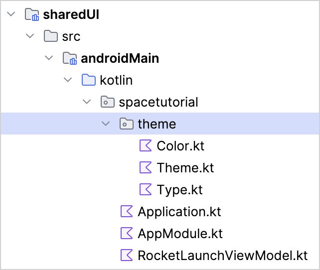

4. In each file inside the `theme` package, change the `package` line to refer to the package you created:

   ```
   package com.jetbrains.spacetutorial.theme
   ```

5. In the `Color.kt` file, add two variables for colors you are going to use for successful and unsuccessful launches:

   ```
   val app_theme_successful = Color(0xff4BB543)
   val app_theme_unsuccessful = Color(0xffFC100D)
   ```

### Implement the presentation logic

Create the main `App()` composable for your application and call it from the `ComponentActivity` class:

   ```
   package com.jetbrains.spacetutorial

   import androidx.compose.material3.pulltorefresh.rememberPullToRefreshState
   import androidx.compose.runtime.Composable
   import androidx.compose.runtime.getValue
   import androidx.compose.runtime.mutableStateOf
   import androidx.compose.runtime.remember
   import androidx.compose.runtime.rememberCoroutineScope
   import androidx.compose.runtime.setValue
   import androidx.compose.ui.tooling.preview.Preview
   import org.koin.androidx.compose.koinViewModel
   import androidx.compose.material3.ExperimentalMaterial3Api

   @OptIn(
     ExperimentalMaterial3Api::class
   )
   @Composable
   @Preview
   fun App() {
       val viewModel = koinViewModel<RocketLaunchViewModel>()
       val state by remember { viewModel.state }
       val coroutineScope = rememberCoroutineScope()
       var isRefreshing by remember { mutableStateOf(false) }
       val pullToRefreshState = rememberPullToRefreshState()
   }
   ```

   Here, you are using the [Koin ViewModel API](https://insert-koin.io/docs/koin-compose/compose-viewmodel) to refer to the `viewModel` you declared in the Android Koin module.
3. Now add the UI code that will implement the loading screen, the column of launch results, and the pull-to-refresh action:

   import androidx.compose.foundation.layout.Arrangement import androidx.compose.foundation.layout.Column import androidx.compose.foundation.layout.fillMaxSize import androidx.compose.foundation.layout.padding import androidx.compose.foundation.lazy.LazyColumn import androidx.compose.foundation.lazy.items import androidx.compose.material3.* import androidx.compose.material3.pulltorefresh.PullToRefreshBox import androidx.compose.material3.pulltorefresh.rememberPullToRefreshState import androidx.compose.runtime.* import androidx.compose.ui.Alignment import androidx.compose.ui.Modifier import androidx.compose.ui.tooling.preview.Preview import androidx.compose.ui.unit.dp import com.jetbrains.spacetutorial.entity.RocketLaunch import com.jetbrains.spacetutorial.theme.AppTheme import com.jetbrains.spacetutorial.theme.app_theme_successful import com.jetbrains.spacetutorial.theme.app_theme_unsuccessful import kotlinx.coroutines.launch import org.koin.androidx.compose.koinViewModel @OptIn(ExperimentalMaterial3Api::class) @Composable @Preview fun App() { val viewModel = koinViewModel<RocketLaunchViewModel>() val state by remember { viewModel.state } val coroutineScope = rememberCoroutineScope() var isRefreshing by remember { mutableStateOf(false) } val pullToRefreshState = rememberPullToRefreshState() AppTheme { Scaffold( topBar = { TopAppBar( title = { Text( "Space Launches", style = MaterialTheme.typography.headlineLarge ) } ) } ) { padding -> PullToRefreshBox( modifier = Modifier .fillMaxSize() .padding(padding), state = pullToRefreshState, isRefreshing = isRefreshing, onRefresh = { isRefreshing = true coroutineScope.launch { viewModel.loadLaunches() isRefreshing = false } } ) { if (state.isLoading && !isRefreshing) { Column( verticalArrangement = Arrangement.Center, horizontalAlignment = Alignment.CenterHorizontally, modifier = Modifier.fillMaxSize() ) { Text("Loading...", style = MaterialTheme.typography.bodyLarge) } } else { LazyColumn { items(state.launches) { launch: RocketLaunch -> Column( verticalArrangement = Arrangement.spacedBy(8.dp), modifier = Modifier.padding(16.dp) ) { Text( text = launch.missionName, style = MaterialTheme.typography.headlineSmall ) Text( text = if (launch.status.id == 3) "Successful" else "Unsuccessful", color = if (launch.status.id == 3) app_theme_successful else app_theme_unsuccessful ) Text( text = "Launch year: ${launch.launchYear}" ) val details = launch.status.description if (details.isNotBlank()) { Text(details) } } HorizontalDivider() } } } } } } }
4. Finally, in the `androidApp/src/main/AndroidManifest.xml`, specify your `MainActivity` class in the `<activity>` tag:

   ```
   <manifest xmlns:android="http://schemas.android.com/apk/res/android">
       ...
       <application
           ...
           <activity
               ...
               android:name="com.jetbrains.spacetutorial.MainActivity">
               ...
           </activity>
       </application>
   </manifest>
   ```

5. Run your Android app: select androidApp from the run configurations menu, choose an emulator, and click the run button. The app automatically runs the API request and displays the list of launches (the background color depends on the Material Theme you generated):

[figure not shown]

You've just created an Android application that has its business logic implemented in the Kotlin Multiplatform module, and its UI runs on native Jetpack Compose.

## Create the iOS application

For the iOS part of the project, you'll make use of [SwiftUI](https://developer.apple.com/xcode/swiftui/) to build the user interface and the Model View View-Model pattern.

IntelliJ IDEA generates an iOS project that is already connected to the shared module. The Kotlin module is exported with the name specified in the `sharedLogic/build.gradle.kts` file (`baseName = "SharedLogic"`), and imported using a regular `import` statement: `import SharedLogic`.

### Add the dynamic linking flag for SQLDelight

By default, IntelliJ IDEA generates projects set up for static linking of iOS frameworks.

To use the native SQLDelight driver on iOS, add the dynamic linker flag that allows Xcode tooling to find the system-provided SQLite binary:

1. In IntelliJ IDEA, select the File | Open Project in Xcode option to open your project in Xcode.
2. In Xcode, click the project name to open its settings.
3. Switch to the Build Settings tab, there switch to the All list, and search for the Other Linker Flags field.
4. Expand the field, press the plus sign next to the Debug field, and paste the `-lsqlite3` string into the Any Architecture | Any SDK.
5. Repeat the process for the Other Linker Flags | Release field.

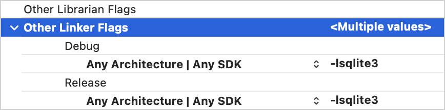

6. Return to IntelliJ IDEA.

### Prepare a Koin class for iOS dependency injection

To use Koin classes and functions in Swift code, create a special `KoinComponent` class and declare the Koin module for iOS.

1. In the `sharedLogic/src/iosMain/kotlin/com/jetbrains/spacetutorial` directory, create the `KoinHelper.kt` file.
2. Add the `KoinHelper` class, which will wrap the `SpaceSDK` class with a lazy Koin injection:

   ```
   package com.jetbrains.spacetutorial

   import org.koin.core.component.KoinComponent
   import com.jetbrains.spacetutorial.entity.RocketLaunch
   import org.koin.core.component.inject

   class KoinHelper : KoinComponent {
       private val sdk: SpaceSDK by inject<SpaceSDK>()

       suspend fun getLaunches(forceReload: Boolean): List<RocketLaunch> {
           return sdk.getLaunches(forceReload = forceReload)
       }
   }
   ```

3. Below the `KoinHelper` class, add the `initKoin()` function, which you will use in Swift to initialize and start the iOS Koin module:

   ```
   import com.jetbrains.spacetutorial.cache.IOSDatabaseDriverFactory
   import com.jetbrains.spacetutorial.network.SpaceApi
   import org.koin.core.context.startKoin
   import org.koin.dsl.module

   fun initKoin() {
       startKoin {
           modules(module {
               single<SpaceApi> { SpaceApi() }
               single<SpaceSDK> {
                   SpaceSDK(
                       databaseDriverFactory = IOSDatabaseDriverFactory(), api = get()
                   )
               }
           })
       }
   }
   ```

Now, you can start the Koin module in your iOS app to use the native database driver with the common `SpaceSDK` class.

### Implement the UI

First, you'll create a `RocketLaunchRow` SwiftUI view for displaying an item from the list. It will be based on the `HStack` and `VStack` views. There will be extensions on the `RocketLaunchRow` structure with useful helpers for displaying the data.

1. In IntelliJ IDEA, make sure you are in the ** Project ** view.
2. Create a new Swift file in the `iosApp/iosApp` folder, next to `ContentView.swift`, and name it `RocketLaunchRow`.
3. Update the `RocketLaunchRow.swift` file with the following code:

   ```
   import SwiftUI
   import SharedLogic

   struct RocketLaunchRow: View {
       var rocketLaunch: RocketLaunch

       var body: some View {
           HStack() {
               VStack(alignment: .leading, spacing: 10.0) {
                   Text("\(rocketLaunch.missionName)")
                       .font(.system(size: 18))
                       .bold()
                       .fixedSize(horizontal: false, vertical: true)
                   Text(launchText).foregroundColor(launchColor)
                   Text("Launch year: \(String(rocketLaunch.launchYear))")
                   Text("\(rocketLaunch.status.description_)")
               }
               Spacer()
           }
       }
   }

   extension RocketLaunchRow {
       private var launchText: String {
           let isSuccess = rocketLaunch.status.id == 3
           return isSuccess ? "Successful" : "Unsuccessful"
       }

       private var launchColor: Color {
           let isSuccess = rocketLaunch.status.id == 3
           return isSuccess ? Color.green : Color.red
       }
   }
   ```

   The list of launches will be displayed in the `ContentView` view, which is already included in the project.
4. In the `ContentView.swift` file, add an extension to the `ContentView` class with a `ViewModel` class which will prepare and manage the data:

   ```
   extension ContentView {
       enum LoadableLaunches {
           case loading
           case result([RocketLaunch])
           case error(String)
       }

       @MainActor
       class ViewModel: ObservableObject {
           @Published var launches = LoadableLaunches.loading
       }
   }
   ```

   The view model (`ContentView.ViewModel`) connects with the view (`ContentView`) via the [Combine framework](https://developer.apple.com/documentation/combine):
   - The `ContentView.ViewModel` class is declared as an `ObservableObject`.
   - The `@Published` attribute is used for the `launches` property, so the view model will emit signals whenever this property changes.
5. Remove the `ContentView_Previews` structure: you won't implement a preview that should be compatible with your view model.
6. Update the body of the `ContentView` class to display the list of launches and add the reload functionality.
   - This is the UI groundwork: you will implement the `loadLaunches` function in the next phase of the tutorial.
   - The `viewModel` property is marked with the `@ObservedObject` attribute to subscribe to the view model.

   ```
   struct ContentView: View {
       @ObservedObject private(set) var viewModel: ViewModel

       var body: some View {
           NavigationView {
               listView()
               .navigationBarTitle("Space Launches")
               .navigationBarItems(trailing:
                   Button("Reload") {
                       self.viewModel.loadLaunches(forceReload: true)
               })
           }
       }

       private func listView() -> AnyView {
           switch viewModel.launches {
           case .loading:
               return AnyView(Text("Loading...").multilineTextAlignment(.center))
           case .result(let launches):
               return AnyView(List(launches) { launch in
                   RocketLaunchRow(rocketLaunch: launch)
               })
           case .error(let description):
               return AnyView(Text(description).multilineTextAlignment(.center))
           }
       }
   }
   ```

7. The `RocketLaunch` class is used as a parameter for initializing the `List` view, so it needs to [conform to the `Identifiable` protocol](https://developer.apple.com/documentation/swift/identifiable). The class already has a property named `id`, so all you should do is add an extension to the bottom of `ContentView.swift`:

   ```
   extension RocketLaunch: Identifiable { }
   ```

### Load the data

To retrieve the data about the rocket launches in the view model, you'll need an instance of the `KoinHelper` class from the Multiplatform library. It will allow you to call the SDK function with the correct database driver.

1. In the `ContentView.swift` file, expand the `ViewModel` class to include a `KoinHelper` object and the `loadLaunches` function:

   ```
   extension ContentView {
       // ...
       class ViewModel: ObservableObject {
           // ...
           let helper: KoinHelper = KoinHelper()

           init() {
               self.loadLaunches(forceReload: false)
           }

           func loadLaunches(forceReload: Bool) {
               // TODO: retrieve data
           }
       }
   }
   ```

2. In the `loadLaunches()` function, call the `KoinHelper.getLaunches()` function (which will proxy the call to the `SpaceSDK` class) and save the result in the `launches` property:

   ```
   func loadLaunches(forceReload: Bool) {
       Task {
           do {
               self.launches = .loading
               let launches = try await helper.getLaunches(forceReload: forceReload)
               self.launches = .result(launches)
           } catch {
               self.launches = .error(error.localizedDescription)
           }
       }
   }
   ```

   When you compile a Kotlin module into an Apple framework, suspending functions can be called using the Swift's `async`/`await` mechanism.

   Since the `getLaunches` function is marked with the `@Throws(Exception::class)` annotation in Kotlin, any exceptions that are instances of the `Exception` class or its subclass will be propagated to Swift as `NSError`. Therefore, all such exceptions can be caught by the `loadLaunches()` function.
3. Go to the app's entry point, the `iOSApp.swift` file, and initialize the Koin module, the view, and the view model:

   ```
   import SwiftUI
   import SharedLogic

   @main
   struct iOSApp: App {
       init() {
           KoinHelperKt.doInitKoin()
       }

       var body: some Scene {
           WindowGroup {
               ContentView(viewModel: .init())
           }
       }
   }
   ```

4. In IntelliJ IDEA, switch to the iosApp configuration, choose an emulator, and run it to see the result:

[figure not shown]

## What's next?

This tutorial features some potentially resource-heavy operations, like parsing JSON and making requests to the database in the main thread. To learn about how to write concurrent code and optimize your app, see the Coroutines guide.

You can also check out these additional learning materials:

- [Use the Ktor HTTP client in multiplatform projects](https://ktor.io/docs/http-client-engines.html#mpp-config)
- [Read about Koin and dependency injection](https://insert-koin.io/docs/setup/why)
- Make your Android application work on iOS
- Learn more about multiplatform project structure.

24 June 2026

Migrating a Jetpack Compose app to Kotlin MultiplatformCreate your Kotlin Multiplatform library – tutorial

© 2010–2026 JetBrains s.r.o. and Kotlin Programming Language contributors  
Licensed under the Apache License, Version 2.0.  
https://kotlinlang.org/docs/multiplatform/multiplatform-ktor-sqldelight.html